# Project: No-show appointments- Nawal Nassif

## Exploratory Data Analysis

### Research Question 1: Do patients receiving sms show up on their appointment more then who did not received one?

```python
# to study if the patients who have received an sms show up on their appointments or not.
#I want to use query to select each group and get its mean sms_received

#Select patients who received an sms
received_sms=df.query('sms_received==1')

#Select patients who did not receive an sms
notreceived_sms=df.query('sms_received==0')

# ensure these queries included each patient exactly once
num_patients = df.shape[0]
num_patients == received_sms['show'].count() + notreceived_sms['show'].count()
```

```
True
```

```python
#get mean show up for patients receivig sms and not receiving sms
mean_received_sms=received_sms['show'].mean()
mean_noreceived_sms=notreceived_sms['show'].mean()
```

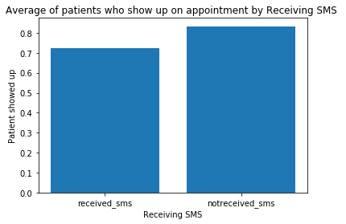

```python
#create a bar chart with proper labels of the above data
locations=[1,2]
heights=[mean_received_sms, mean_noreceived_sms]
labels=['received_sms','notreceived_sms']
plt.bar(locations, heights, tick_label=labels)
plt.title('Average of patients who show up on appointment by Receiving SMS ')
plt.xlabel('Receiving SMS')
plt.ylabel('Patient showed up');
```

## Comments and interpretations

It looks that the number of patients showing up on appointment and who didn't receive an sms is higher than patients who show up on appointment and receive an sms. Therefore, receiving or not an sms didn't lead the decision of patient to show up on appointment.

### Research Question 2 : Do patients who are enrolled in scholarship with Bolsa Familia show up on their scheduled appointment more then other patients?

```python
#create a function for my bar plot of the Data (this code was presented as an example of my reviewer and I try it,
#however, I create below a simple function)
def dtmeanbarplot (df,xVar, labels=None):
    """this function is created to automate the visualization of my dataset
    type used is the bar chart
    data reflect the mean value of patients who show up on their appointments according to one variable """

    # set plot dimensions
    plt.figure(figsize=(8,5))

    #create data for plot
    data=df.groupby(xVar).show.mean()
    plt.bar(data.index, data, tick_label=labels)

    #title the bar chart
    plt.title(f'Proportion of Patients who show up:{xVar}'.title())
    plt.xlabel(xVar.title())
    plt.ylabel("Proportion of Patients Who Show Up");
```

```python
# select patients who show-up on their appointment
show_up=df.show==True

# select patients who didn't show up on their appointment
not_show_up=df.show==False
```

```python
# calculate the mean of patient receiving scholarship and show up on their appointment
df.scholarship[show_up].mean()
```

```
0.093903047342644652
```

```python
# calculate the mean of patient receiving scholarship and didn't show up on their appointment
df.scholarship[not_show_up].mean()
```

```
0.11550696715802679
```

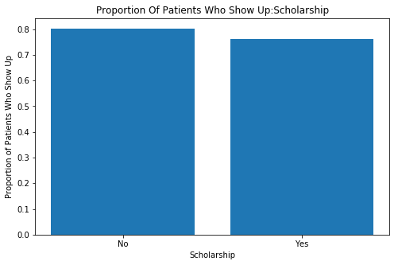

```python
#create a bar chart of patient who show up on their appointment according to scholarship;
labels=['No', 'Yes']

#call the function
dtmeanbarplot(df,'scholarship', labels=labels);
```

## Comments and interpretations

Based on the above calculations: patients who did not receive any scholarship show up on their appointement a little bit more than patients who received scholarship. This conclusion is confirmed by the above bar chart.

### Research Question 3 : Do patients with specific medical conditions or specific lifestyle show up on their appointments more then other patients? and what about many medical conditions?

```python
#create a function to count values of different variables
def count_var(df,Var):
    var=df.columns
    X=df[Var].value_counts()
    return X
```

```python
# In order to respond to the question number 3; I want to create a score of sum of number
# of specific medical condition or lifestyle for each patient.
#To do this let overview the values related to medical conditions and lifestyle.

# values related to hypertension; call function
count_var(df,'hypertension')
```

```
0    88726
1    21801
Name: hypertension, dtype: int64
```

```python
# values related to diabetes; call function
count_var(df,'diabetes')
```

```
0    102584
1      7943
Name: diabetes, dtype: int64
```

```python
# values related to alcoholism; call function
count_var(df,'alcoholism')
```

```
0    107167
1      3360
Name: alcoholism, dtype: int64
```

```python
# values related to handcap; call function
count_var(df,'handcap')
```

```
0    108286
1      2042
2       183
3        13
4         3
Name: handcap, dtype: int64
```

```python
# since all medical conditions include only 2 values (True, False), except
# handcap where patients are classified into 4 categories. I want to adjust all
# values to be (True or False) where true is the presence of any value (1,2,3,4) meaning handcap
#condition and false express no handcap conditions
df["handcap"].replace({2:1, 3:1, 4:1}, inplace=True)
```

```python
count_var(df,'handcap') # to confirm the changes
```

```
0    108286
1      2241
Name: handcap, dtype: int64
```

```python
#check if the hypertension is associated with the show up on appointment
df.hypertension[show_up].mean(), df.hypertension[not_show_up].mean()
```

```
(0.20439189189189189, 0.16900398763385457)
```

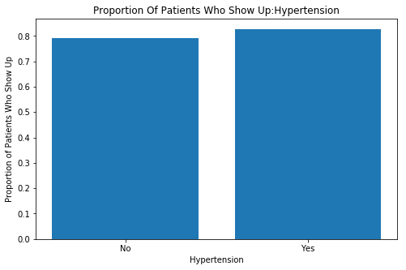

```python
#create of bar chart: show-up of patient diagnosed or not with hypertension
labels=['No', 'Yes']

#call the function
dtmeanbarplot(df,'hypertension', labels=labels);
```

## Comments and interpretations

Patients who are diagnosed with hypertension show up on their appointments more than healthy patients.

```python
#create of bar chart: show-up of patient diagnosed or not with diabetes
df.diabetes[show_up].mean(), df.diabetes[not_show_up].mean()
```

```
(0.073836840195900602, 0.064070970921636272)
```

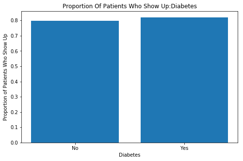

```python
#create of bar chart: show-up of patient diagnosed or not with diabetes
labels=['No', 'Yes']

#call the function
dtmeanbarplot(df,'diabetes', labels=labels);
```

## Comments and interpretations

Patients who have diabetes show up on their appointment more than healthy patients.

```python
#create of bar chart: show-up of patient diagnosed or not with alcoholism
df.alcoholism[show_up].mean(), df.alcoholism[not_show_up].mean()
```

```
(0.030416742245601307, 0.030332900219543886)
```

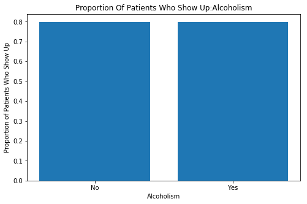

```python
#create of bar chart: show-up of patient with alcoholism on their appointment
labels=['No', 'Yes']

#call the function
dtmeanbarplot(df,'alcoholism', labels=labels);
```

## Comments and interpretations

```python
#create of bar chart: show-up of patient with or without handcap condition
df.handcap[show_up].mean(), df.handcap[not_show_up].mean()
```

```
(0.020791764919281697, 0.018235584031542632)
```

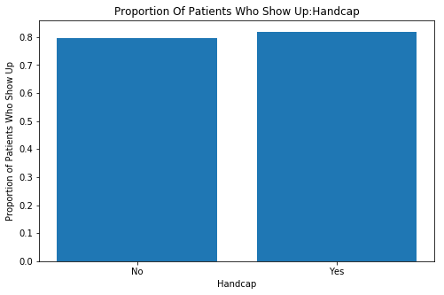

```python
#create of bar chart: show-up of patient with handcap condition on their appointment
labels=['No', 'Yes']

#call the function
dtmeanbarplot(df,'handcap', labels=labels);
```

## Comments and interpretations

Patients who are diagnosed with handcap condition show up on their appointment a little bit more than healthy patients.

```python
# now let's create the score of each patient
# the value of this score will range between 0 (patient doesn't have any medical
# condition) and 4 if patient do have all the below medical conditions

df['medical_cond']=df['hypertension']+df['diabetes']+df['alcoholism']+df['handcap']
```

```python
#Use groupby to get the mean show for each patient conditions
med_cond_means=df.groupby('medical_cond').show.mean()
med_cond_means
```

```
medical_cond
0    0.790727
1    0.820725
2    0.821363
3    0.846278
4    0.692308
Name: show, dtype: float64
```

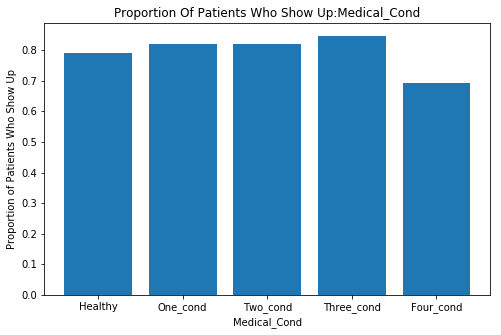

```python
# create a bar chart of proportion of patients who show up on their appointments according to their medical conditions
labels=['Healthy', 'One_cond','Two_cond','Three_cond','Four_cond']

#call the function
dtmeanbarplot(df,'medical_cond', labels=labels)
```

## Comments and interpretations

### Research Question 4 : Do the duration between scheduled and appointment dates is associated with the show up of patients on their appointments?

```python
# let's truncate the date from the scheduledday and the appoitmentday
df['scheduleddate'] = pd.to_datetime(df['scheduledday']).dt.date
df['appointmentdate']=pd.to_datetime(df['appointmentday']).dt.date
df.head(1) # to confirm changes
```

|  | scheduledday | appointmentday | scholarship | hypertension | diabetes | alcoholism | handcap | sms_received | show | medical_cond | scheduleddate | appointmentdate |
| --- | --- | --- | --- | --- | --- | --- | --- | --- | --- | --- | --- | --- |
| 0 | 2016-04-29 18:38:08 | 2016-04-29 | 0 | 1 | 0 | 0 | 0 | 0 | 1 | 1 | 2016-04-29 | 2016-04-29 |

```python
#let's calculate the duration between the scheduled date and the appointment date in days
df['interval_days'] = (df['appointmentdate'] - df['scheduleddate']).dt.days
df.head(1)# to confirm the results
```

|  | scheduledday | appointmentday | scholarship | hypertension | diabetes | alcoholism | handcap | sms_received | show | medical_cond | scheduleddate | appointmentdate | interval_days |
| --- | --- | --- | --- | --- | --- | --- | --- | --- | --- | --- | --- | --- | --- |
| 0 | 2016-04-29 18:38:08 | 2016-04-29 | 0 | 1 | 0 | 0 | 0 | 0 | 1 | 1 | 2016-04-29 | 2016-04-29 | 0 |

```python
#calculate the mean of interval_days in days
df.interval_days.mean()
```

```
10.183701719941734
```

```python
#calculate the mean interval days of patient showing up on their appointment
mean_intdays_show=df.interval_days[show_up].mean()
mean_intdays_show
```

```
8.7546594413205145
```

```python
#calculate the mean interval days of patient who did not show up on their appointment
mean_intdays_not_show=df.interval_days[not_show_up].mean()
mean_intdays_not_show
```

```
15.83148886598862
```

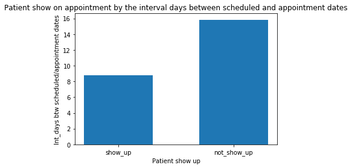

```python
#create a bar chart of patient show appointment by the interval days between scheduled and appointment dates
locations=[1,2]
heights=[mean_intdays_show, mean_intdays_not_show]
labels=['show_up', 'not_show_up']
plt.bar(locations, heights, tick_label=labels, width=0.6)
plt.title('Patient show on appointment by the interval days between scheduled and appointment dates')
plt.xlabel('Patient show up')
plt.ylabel('Int_days btw scheduled/appointment dates');
```

[output not shown]

[figure not shown]

```python
# create a bar chart of proportion of patients who show up on their appointments according to their medical conditions
labels=['show_up', 'not_show_up']

#call the function
dtmeanbarplot(df,'interval_days', labels=labels)
```

## Comments and Interpretations

Based on the above calcualtion, the time between scheduled date and appointment date is approximately 10 days. The interval days of patients who show up on their appointment is lower (8.7days) than the interval days of patients who didn't show on their appoitments (15.8 days).

## Conclusion

We can conclude that:

## Limitations

> 1. One of the limitations is that we conduct a descriptive statistics without any statistical tests, therefore, causality and relationships between variables are not performed.
> 2. Data include the location of patient but did not give any further details concerning the distance between hometown and medical centers which can be a factor for not showing on appointment.

## Question for reviewer:

When I check my data for duplication by using the function (duplicated().sum()), the results after running the code was 722, therefore, I drop them and check the shape of modified data and the answer was 109805. But after finalization of my project and rerun the kernel with all updates. Duplicates are always calculated as 0. I am confused about this issue and I tried many time to investigate this issue and research it without any success. Thank you in advance for your cooperation.

```python
from subprocess import call
call(['python', '-m', 'nbconvert', 'Investigate_a_Dataset.ipynb'])
```